# Experiemts with tf-idf #2

James Muguira

1/10/2019

# Introduction

The first experiement in this series applied term frequency (tf) and tf-idf to a set of documents to discover hidden structure. We are using two documents on design thinking as our reference data. We found that tf-idf could help expose structure from a focused document like the Gasparanini paper. With the Stanford guide on design thinking, it was not as clear what the paper was about.

This expereiment will use tf-idf and bigrams to further explore the documents.

In general an ngram is a grouping of terms from a source document. We are using bigrams, or ngrams of length 2 words. You can create ngrams of any length.

As with the first experiment we gather our data into a tidy format. The goal this time is to create a single tidy tibble of bigrams. This tidy tibble will contain all of the words for both documents. In this case, the tidy format will contain a pair of words for each row of the tibble.

Our 2 document are:

- https://dschool-old.stanford.edu/sandbox/groups/designresources/wiki/36873/attachments/74b3d/ModeGuideBOOTCAMP2010L.pdf
- https://www.researchgate.net/publication/273126653_Perspective_and_Use_of_Empathy_in_Design_Thinking/download

```r
pdf_stan <- pdf_text("./ModeGuideBOOTCAMP2010.pdf")
pdf_gasparanini <- pdf_text("./gasparini-final-3.pdf")

#
# bring our data
pdf_stan <- pdf_text("./ModeGuideBOOTCAMP2010.pdf")
pdf_gasparanini <- pdf_text("./gasparini-final-3.pdf")
#
# turn our data in to tbls and add a column heading
df_stan <- data_frame(line=1:11,text=pdf_stan)
df_stan <- mutate(df_stan, book=rep("stanford", nrow(df_stan)))

df_gasparanini <- data_frame(line=1:7, text=pdf_gasparanini)
df_gasparanini <- mutate(df_gasparanini, book=rep("ovr", nrow(df_gasparanini)))
#
# bind the 2 tibbles into a single tibble
bag_of_words <- rbind(df_stan, df_gasparanini)
```

Now that the data is in a tibble, let’s clean it and arrange it. Viewing the data at this point shows it to be arranged as 18 rows of strings of words. We can create bigrams from these strings using unnest_tokens. We then can clean up the tidy tibble to remove stop words and numbers.

The process is to create the rows of bigrams, separate the pairs of words in the bigrams, check and remove the stop words, numbers and then unite the result.

```r
data("stop_words")

bow <- bag_of_words %>%
  unnest_tokens(bigram, text, token = "ngrams", n = 2)

bow_separated <- bow %>%
  separate(bigram, c("word1", "word2"), sep=" ")

#
# drop stop words and numbers
bow_filtered <- bow_separated %>%
  filter(!word1 %in% stop_words$word) %>%
  filter(!word2 %in% stop_words$word) %>%
  filter(!grepl(pattern="[0123456789]+", word1)) %>%
  filter(!grepl(pattern="[0123456789]+", word2))

# put the data back into a bigram formatted tibble
bow_united <- bow_filtered %>%
  unite(bigram, word1, word2, sep=" ")
```

The result at this point is an enhanced view of the content of each paper. On the left, the results show the Gasparanini paper to contain “Designerly Thinking”, “congitive empathy” and “user journey”. The paper on the right contains a more wide ranging set of frequent terms. This wider range better reflects the nature of the Stanford paper, since it is a “how-to” guide.

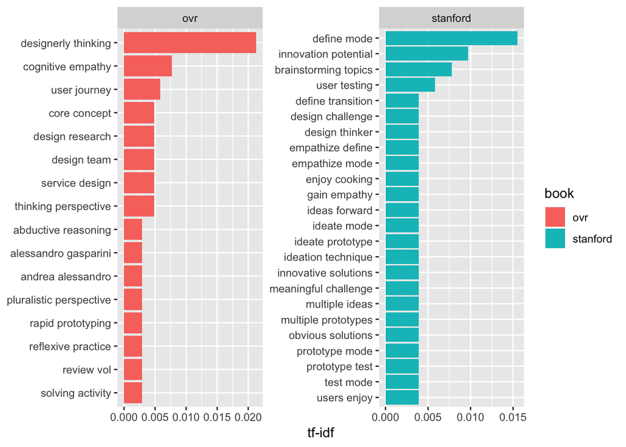

```r
bow_united %>%
  count(bigram, book, sort=TRUE) %>%
  bind_tf_idf(bigram, book, n) %>%
  arrange(desc(tf_idf)) %>%
  mutate(bigram = factor(bigram, levels = rev(unique(bigram)))) %>%
  group_by(book) %>%
  top_n(10) %>%
  ungroup %>%
  ggplot(aes(bigram, tf_idf, fill = book)) +
  geom_col(show.legend = TRUE) +
  labs(x = NULL, y = "tf-idf") +
  facet_wrap(~book, ncol = 2, scales = "free") +
  coord_flip()
```